# Errors in numerical solutions

Since numerical solutions are an approximation, and since the computer program that executes the numerical method might have errors, a numerical solution needs to be examined closely.

There are three major sources of error in computation:

- human errors,
- truncation errors, and
- round-off errors.

## Human errors

Typical human errors are arithmetic errors, and/or programming errors: These errors can be very hard to detect unless they give obviously incorrect solution. In discussing errors, we shall assume that human errors are not present.

- Example of arithmetic errors: When parentheses or the rules about orders of operation are misunderstood or ignored:
  - You can remember the correct order of operations rules by the mnemonic PEMDAS, which says to compute anything inside Parentheses first, then compute Exponential expressions (powers) next, then compute Multiplications and Divisions from left to right, and finally compute Additions and Subtractions from left to right. The highest priority for parentheses means that you should follow the remaining rules for anything inside the parentheses to arrive at a result for that part of the calculation.

## Truncation and Round-off errors

- Error in computation is the difference between the exact answer $X_{exact}$ and he computed answer $X_{computed}$. This is also known as true error:

$$true\ error = X_{computed} - X_{exact} $$

- Since we are usually interested in the magnitude or absolute value of the error we define

$$true\ absolute\ error = |X_{computed} - X_{exact}| $$

- The absolute error can sometimes be misleading. Even if the absolute error is small in magnitude, the approximation may still be grossly inaccurate if the exact value $X_{exact}$ is even smaller in magnitude. For this reason, it is preferable to measure accuracy in terms of the relative error.

$$true\ relative\ error = \frac{|X_{computed} - X_{exact}|}{|X_{exact}|} $$

### Truncation error:

Numerical methods use approximations for solving problems. The errors introduced by the approximations are the truncation errors. For example, consider the Taylor series expansion $$ e^{x} = 1 + x + \frac{x^2}{2!} + \dots + \frac{x^n}{n!} + \dots$$

If the formula is used to calculate $e^{0.3}$ we get $$ e^{0.3} = 1 + 0.3 + \frac{0.3^2}{2!} + \dots + \frac{0.3^n}{n!} + \dots$$

Where do we stop the calculation? How many terms do we include? Theoretically the calculation will never stop. There are always more terms to add on. If we do stop after a finite number of terms, we will not get the exact answer. For example if we do take the first four terms as the approximation we get

$$ r = e^{0.3} \approx 1 + 0.3 + \frac{0.3^2}{2!} + \dots + \frac{0.3^3}{3!} = \bar{r} $$

For this calculation, the truncation error is

$$truncation\ error = r - \bar{r}$$

Another example of truncation error that is the approximate calculation of derivatives. The value of the derivative of a function at a point can be approximated by the expression:

$$\frac{df}{dx}|x=x_1 = \frac{f(x_2) - f(x_1)}{x_2 - x_1}$$

where $x_2$ is a point near $x_1$. The difference between the value of the true derivative and the value that is calculated with this equation is called a truncation error. The truncation error is dependent on the specific numerical method or algorithm used to solve a problem. The truncation error is independent of round-off error.

### Round-off error

Numbers can be represented in various forms. The familiar decimal system (base 10) uses ten digits $0, 1 , \dots ,9$. A number is written by a sequence of digits that correspond to multiples of powers of 10.

[figure not shown]

In general, however, a number can be represented using other bases. A form that can be easily implemented in computers is the binary (base 2) system. In the binary system, a number is represented by using the two digits 0 and 1. A number is then written as a sequence of zeros and ones that correspond to multiples of powers of 2.

[figure not shown]

- Computers store and process numbers in binary (base 2) form.
- Each binary digit (one or zero) is called a bit (for binary digit).
- Binary arithmetic is used by computers because modern transistors can be used as extremely fast switches.
- Therefore, a network of these may be used to represent strings of numbers with the 1 referring to the switch being in the **on** position and 0 referring to the **off** position. Various operations are then performed on these sequences of ones and zeros.
- Computer memory has a finite capacity. This obvious fact has far reaching implications on the representation of real numbers, which in general do not have a finite uniform representation.
- To accommodate large and small numbers, real numbers are written in floating point representation.
- A floating-point number is typically expressed in the scientific notation, with a fraction ($F$), and an exponent ($e$) of a certain radix ($r$), in the form of $F \times r^e$. Decimal numbers use radix of 10 ($F \times 10^e$); while binary numbers use radix of 2 ($F \times 2^e$).

Any real number $x$ is accurately representable by an infinite sequence of digits of the form

$$x = \pm (1.d_1d_2d_3\dots) \times 2^e$$

where $e$ is an integer exponent. The (possibly infinite) set of binary digits $d_i$ each have a value 0 or 1 is called mantissa. The decimal value of this mantissa is

$$1.d_1d_2d_3\dots = 1 + \frac{d_1}{2} + \frac{d_2}{2^2} + \frac{d_3}{2^3} + \dots$$

For instance, the binary representation $x = (1.10100) \times 2^1$ has in decimal the value

$$x = (1 + 1/2 + 1/8) \times 2 = 3.25$$

Of course, it should be clear that the choice of a binary representation is just one of many possibilities, indeed a convenient choice when it comes to computers.

To represent any real number on the computer, we associate to $x$ a floating point representation $fl(x)$ of a form similar to that of our previous $x$ but with only $t$ digits, so

$$fl(x) = sign(x) \times (1.d_1d_2d_3d_{t-1}d_t) \times 2^e$$

for some $t$ that is fixed in advance. Storing this fraction in memory thus requires $t$ bits. The exponent $e$ must also be stored in a fixed number of bits and therefore must be bounded, say between a lower bound $L$ and an upper bound $U$.

- Without being aware of any further details it should already be clear that representing $x$ by $fl(x)$ necessarily causes an error also known as round-off error.
- Given a real number $x$, the machine number obtained by rounding $x$ is denoted by $fl(x)$.

According to the IEEE-754 (Institute of Electrical and Electronics Engineers) standard, computers store numbers and carry out calculations in single precision or in double precision.

- In single precision, the numbers are stored in a string of 32 bits (4 bytes), and in double precision in a string of 64 bits (8 bytes).
- In both cases the first bit stores the sign (0 corresponds to + and 1 corresponds to -) of the number. The next 8 bits in single precision (11 bits in double precision) are used for storing the exponent. The following 23 bits in single precision (52 bits in double precision) are used for storing the mantissa.

[figure not shown]

### Example (single precision)

| Sign (1 bit) | Exponent (8 bits) | Mantissa (23 bits) |
| --- | --- | --- |
| 1 | 10000001 | 01101000000000000000000 |

- Sign is: -1
- Exponent is $(2^7 + 2^0) - 127 = 129 - 127$ = 2, bias is -127, and is added of the exponent.
- Mantissa is 1 + $2^{-2}$ + $2^{-3}$ + $2^{-5}$
- Then:

$$x = (-1) \times (1 + 2^{-2} + 2^{-3} + 2^{-5}) \times 2^2 = -5.625$$

### Example: now your turn

The following can be considered as a double precision word: $$0100000001111110100000000000000000000000000000000000000000000000$$

- Interpret it as a decimal.

## Conversion from Decimal to Floating Point Representation

Represent the decimal number 329.390625 using floating point numbers.

- First convert it to binary scientific notation, start with what there is to the left of the decimal point to binary.
  - 329 is equivalent to the binary 101001001.
- Then, what is to the right of the decimal point: 0.390625.

```
0.390625 * 2 = 0.78125   0
0.78125  * 2 = 1.5625    1
0.5625   * 2 = 1.125     1
0.125    * 2 = 0.25      0
0.25     * 2 = 0.5       0
0.5      * 2 = 1         1
0
```

Then we have: $101001001.011001$, Then we have: in binary scientific notation: $1.01001001011001 \times 2^8$.

### Wrapping up

The sign is positive, so the sign field is 0.

The exponent is 8. 8 + 127 = 135, so the exponent field is 10000111.

The mantissa is merely 01001001011001 (remember the implied 1 of the mantissa means we don't include the leading 1) plus however many 0s we have to add to the right side to make that binary number 23 bits long.

| Sign (1 bit) | Exponent (8 bits) | Mantissa (23 bits) |
| --- | --- | --- |
| 0 | 10000111 | 01001001011001000000000 |

## Floating point special numbers

[figure not shown]

See: https://en.wikibooks.org/wiki/Floating_Point/Special_Numbers

## Floating point accuracy

A central question is how accurate the floating point representation of the real numbers is. Specifically, we ask how large the relative error in such a representation, defined by

$$\frac{|fl(x) - x|}{|x|}$$

Modern floating point systems guarantee that this relative error is bounded by $\eta$ which is called rounding unit, machine precision, machine epsilon and more. The usual floating point word in the standard floating point system, which is what Matlab uses by default, has 64 bits. Of these, 52 bits are devoted to the mantissa while the rest store the sign and the exponent. Hence the rounding unit is

$$\eta = 2^{−53} \approx 1.1\times 10^{−16}.$$

Even if number representations were exact in our floating point system, arithmetic operations involving such numbers introduce roundoff errors. These errors can be quite large in the relative sense.

The IEEE standard however requires exact rounding, which yields that the relative error in each arithmetic operation is also bounded by $\eta$.

# Order and rate of convergence

Iteration is a common approach widely used in various numerical methods. It is the hope that an iteration in the general form of $x_{n+1}=g(x_n)$ will eventually converge to the true solution $x^*$ of the problem at the limit when $n\rightarrow \infty$. The concern is whether this iteration will converge, and, if so, the rate of convergence. Specifically we use the following to represent how quickly the error $e_n=x_n-x^*$ converges to zero:

$$ \lim\limits_{n\rightarrow\infty}\frac{| e_{n+1}|}{|e_{n}|^p } = \lim_{n\rightarrow\infty}\frac{| x_{n+1}-x^*|}{| x_n-x^*|^p}=\mu $$

Here $p\ge 1$ is called the order of convergence, the constant $\mu$ is the rate of convergence or asymptotic error constant.

This expression may be better understood when it is interpreted as $\vert e_{n+1}\vert=\mu \vert e_n\vert^p$ when $n\rightarrow\infty$. Obviously, the larger $p$ and the smaller $\mu$, the more quickly the sequence converges.

Consider the following cases:

- If $p=1$ and $0<\mu<1$, $\vert e_{n+1}|=\mu| e_n|<| e_n|$, then
  - if $\mu=1$, the convergence is sublinear
  - if $0<\mu<1$, the convergence is linear with the rate of convergence of $\mu$.
  - if $\mu=0$, the convergence is superlinear
- If $p=2$, $| e_{n+1}|=\mu| e_n|^2,\;\;(\mu>0)$, the convergence is quadratic.
- If $p=3$, $|e_{n+1}|=\mu| e_n|^3,\;\;(\mu>0)$, the convergence is cubic.
- Etc.

Examples:

- $|e_n| = 1/n$, the sequence is $1,\;1/2,\;1/3,\;1/4,\;1/5,\; \cdots$

$$\lim_\limits{n \rightarrow \infty} \frac{1/(n+1)}{1/n^p} = \lim_\limits{n \rightarrow \infty}\frac{n^p}{n+1} = 1$$

This is a sublinear and (logarithmical) convergence as only when $p=1$ will the limit be a constant $\mu=1$.

- $| e_n|=1/2^n$, the sequence is $1/2,\; 1/4,\; 1/8,\; 1/16,\; 1/32,\; \cdots$

$$\lim_\limits{n \rightarrow \infty} \frac{1/2^{n+1}}{1/2^{np}} = \lim_\limits{n \rightarrow \infty}\frac{2^{np}}{2^{n+1}}=\frac{1}{2}.$$

This is a linear convergence of order $p=1$ and rate $\mu=1/2$.

- $| e_n|=1/2^{2^n}$, the sequence is $1/4,\; 1/16,\; 1/256,\;1/65536,\; \cdots$

$$ \lim_\limits{n \rightarrow \infty} \frac{1/2^{2^{n+1}}}{(1/2^{2^{n}})^p} =\frac{(2^{2^n})^p}{2^{2^{n+1}}} = \frac{(2^{2^n})^p}{2^{2\times 2^{n}}} =\frac{(2^{2^n})^p}{(2^{2^{n}})^2}.$$

This is superlinear, specifically quadratic, convergence of order $p=2$ and rate $\mu=1$. In fact, it is quadratically convergent.

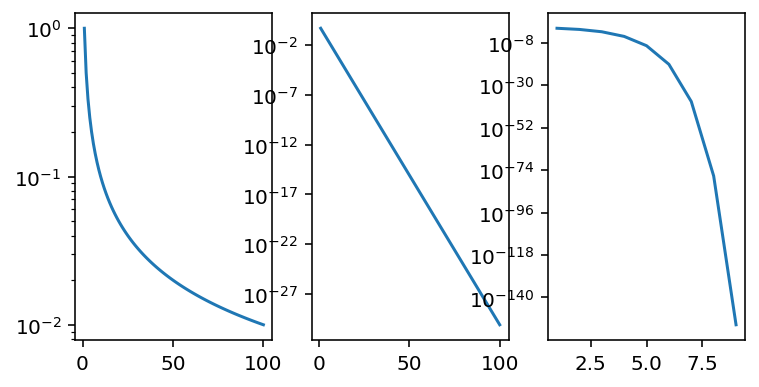

```python
import numpy as np
import matplotlib.pyplot as plt

plt.figure(figsize=(6,3))

plt.subplot(1, 3, 1)
e = [1/n for n in range(1,101)]
plt.semilogy(range(1,101),e)

plt.subplot(1, 3, 2)
e = [1/(2**n) for n in range(1,101)]
plt.semilogy(range(1,101),e)

plt.subplot(1, 3, 3)
e = [1/(2**(2**n)) for n in range(1,10)]
plt.semilogy(range(1,10),e)
```

# Sources and resources:

- https://users.cs.duke.edu/~raw/cps104/TWFNotes/floating.html
- https://www.h-schmidt.net/FloatConverter/IEEE754.html
- https://www.mathworks.com/help/matlab/matlab_prog/floating-point-numbers.html
- https://medium.com/@jollyfish/integer-overflow-underflow-and-floating-point-imprecision-6ba869a99033
- https://binary-system.base-conversion.ro/convert-real-numbers-from-decimal-system-to-32bit-single-precision-IEEE754-binary-floating-point.php
- http://fourier.eng.hmc.edu/e176/lectures/NM/NM.html
- https://en.wikipedia.org/wiki/Rate_of_convergence